# Insertion Sort

Insertion sort adalah algoritma pengurutan sederhana yang bekerja dengan cara memasukkan setiap elemen dari daftar yang belum diurutkan secara iteratif ke posisi yang benar dalam bagian daftar yang sudah diurutkan. Ini seperti mengurutkan kartu remi di tangan Anda. Anda membagi kartu menjadi dua kelompok: kartu yang sudah diurutkan dan kartu yang belum diurutkan. Kemudian, Anda mengambil kartu dari kelompok yang belum diurutkan dan meletakkannya di tempat yang tepat dalam kelompok yang sudah diurutkan.

- Mulailah dengan elemen kedua karena elemen pertama diasumsikan sudah terurut.
- Bandingkan elemen kedua dengan elemen pertama; jika elemen kedua lebih kecil, tukar posisinya.
- Pindah ke elemen ketiga, bandingkan dengan dua elemen pertama, dan letakkan pada posisi yang benar.
- Ulangi hingga seluruh array terurut.

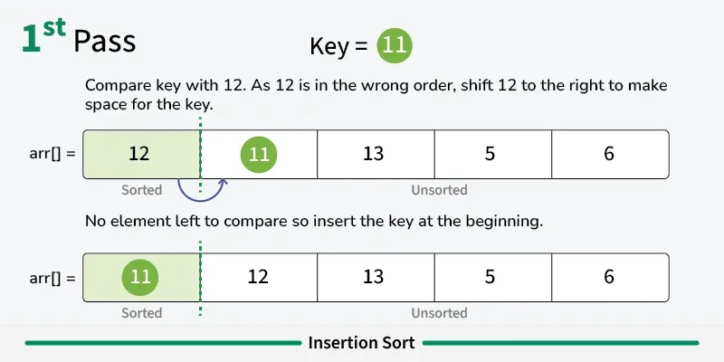

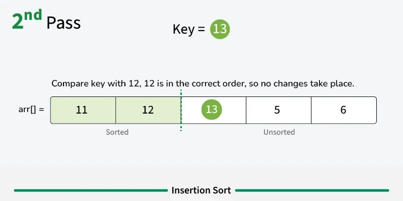

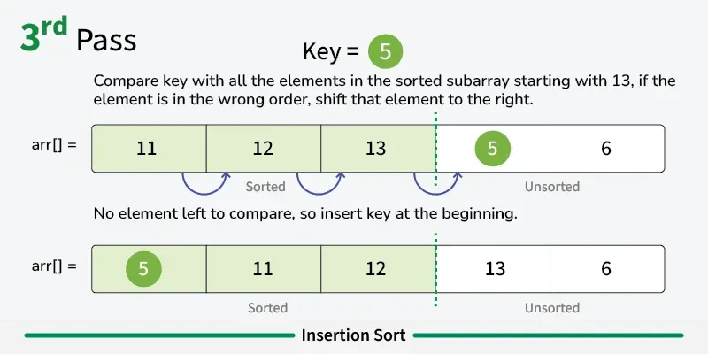

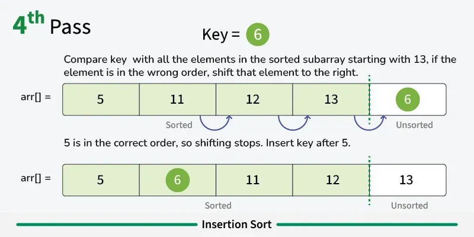

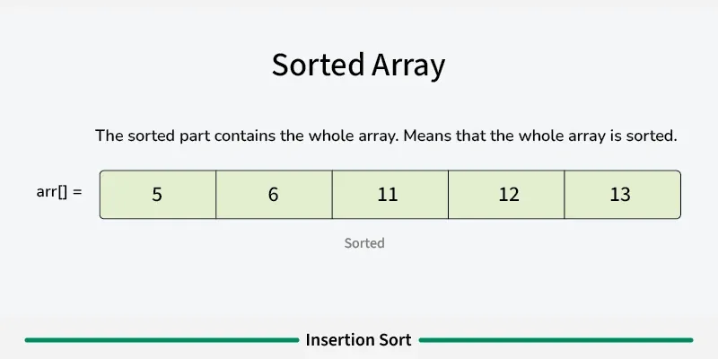

```python
# Python program for implementation of Insertion Sort

# Function to sort array using insertion sort
def insertionSort(arr):
    for i in range(1, len(arr)):
        key = arr[i]
        j = i - 1

        # Move elements of arr[0..i-1], that are
        # greater than key, to one position ahead
        # of their current position
        while j >= 0 and key < arr[j]:
            arr[j + 1] = arr[j]
            j -= 1
        arr[j + 1] = key

# A utility function to print array of size n
def printArray(arr):
    for i in range(len(arr)):
        print(arr[i], end=" ")
    print()

# Driver method
if __name__ == "__main__":
    arr = [12, 11, 13, 5, 6]
    insertionSort(arr)
    printArray(arr)
```

```
5 6 11 12 13
```

[figure not shown]

arr = {23, 1, 10, 5, 2} Awal: Elemen saat ini adalah 23 Elemen pertama dalam larik diasumsikan sudah terurut. Bagian yang diurutkan hingga indeks ke-0 adalah : [23] Percobaan Pertama: Bandingkan 1 dengan 23 (elemen saat ini dengan bagian yang diurutkan). Karena 1 lebih kecil, masukkan 1 sebelum 23 . Bagian yang diurutkan hingga indeks ke-1 adalah: [1, 23] Tahap Kedua: Bandingkan 10 dengan 1 dan 23 (elemen saat ini dengan bagian yang diurutkan). Karena 10 lebih besar dari 1 dan lebih kecil dari 23 , masukkan 10 di antara 1 dan 23 . Bagian yang diurutkan hingga indeks ke-2 adalah: [1, 10, 23] Lintasan Ketiga: Bandingkan 5 dengan 1 , 10 , dan 23 (elemen saat ini dengan bagian yang diurutkan). Karena 5 lebih besar dari 1 dan lebih kecil dari 10 , masukkan angka 5 di antara 1 dan 10. Bagian yang diurutkan hingga indeks ke-3 adalah : [1, 5, 10, 23] Lintasan Keempat: Bandingkan 2 dengan 1, 5, 10 , dan 23 (elemen saat ini dengan bagian yang diurutkan). Karena 2 lebih besar dari 1 dan lebih kecil dari 5, masukkan 2 di antara 1 dan 5 . Bagian yang diurutkan hingga indeks ke-4 adalah: [1, 2, 5, 10, 23] Susunan Akhir: Array yang sudah diurutkan adalah: [1, 2, 5, 10, 23]

## Analisis Kompleksitas Pengurutan Penyisipan

### Kompleksitas Waktu

- Kasus terbaik: O(n) , jika daftar sudah diurutkan, di mana n adalah jumlah elemen dalam daftar.
- Kasus rata-rata: O(n² ) , jika daftar diurutkan secara acak.
- Kasus terburuk: O(n² ) , jika daftar tersebut dalam urutan terbalik.

### Kompleksitas Ruang

Ruang Tambahan: O(1), Pengurutan penyisipan membutuhkan ruang tambahan O(1) , menjadikannya algoritma pengurutan yang efisien dalam penggunaan ruang.

## Keuntungan dan Kerugian dari Insertion Sort

### Keuntungan

- Sederhana dan mudah diterapkan.
- Algoritma pengurutan yang stabil .
- Efisien untuk daftar kecil dan daftar yang hampir terurut.
- Efisien dalam hal penggunaan ruang karena merupakan algoritma in-place.
- Adaptif. Jumlah inversi berbanding lurus dengan jumlah pertukaran. Misalnya, tidak ada pertukaran yang terjadi untuk array yang sudah diurutkan dan hanya membutuhkan waktu O(n).

### Kekurangan

- Tidak efisien untuk daftar yang besar.
- Tidak seefisien algoritma pengurutan lainnya (misalnya, merge sort, quick sort) untuk sebagian besar kasus.

## Penerapan Insertion Sort

Algoritma pengurutan sisipan (insertion sort) umumnya digunakan dalam situasi di mana:

- Daftarnya pendek atau hampir terurut.
- Kesederhanaan dan stabilitas itu penting.
- Digunakan sebagai subrutin dalam Bucket Sort
- Dapat berguna ketika array sudah hampir terurut (sangat sedikit inversi ).
- Karena Insertion Sort cocok untuk array berukuran kecil, algoritma ini digunakan dalam algoritma Hybrid Sorting bersama dengan algoritma efisien lainnya seperti Quick Sort dan Merge Sort. Ketika ukuran sub-array menjadi kecil, kita beralih ke Insertion Sort dalam algoritma rekursif ini. Misalnya, IntroSort dan TimSort menggunakan Insertion Sort.

```python
my_array = [64, 34, 25, 12, 22, 11, 90, 5]

n = len(my_array)
for i in range(1,n):
    insert_index = i
    current_value = my_array.pop(i)
    for j in range(i-1, -1, -1):
        if my_array[j] > current_value:
            insert_index = j
    my_array.insert(insert_index, current_value)

print("Sorted array:", my_array)
```

```
Sorted array: [5, 11, 12, 22, 25, 34, 64, 90]
```

## Peningkatan Insertion Sort

Algoritma Insertion Sort masih bisa ditingkatkan sedikit lagi.

Cara kode di atas pertama-tama menghapus suatu nilai lalu memasukkannya ke tempat lain sangat intuitif. Ini mirip dengan cara Anda melakukan Insertion Sort secara fisik dengan setumpuk kartu, misalnya. Jika kartu bernilai rendah diurutkan ke kiri, Anda mengambil kartu baru yang belum diurutkan, dan memasukkannya ke tempat yang tepat di antara kartu-kartu lain yang sudah diurutkan.

Masalah dengan cara pemrograman ini adalah ketika menghapus suatu nilai dari array, semua elemen di atasnya harus digeser satu indeks ke bawah:

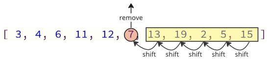

Dan ketika memasukkan kembali nilai yang dihapus ke dalam array, ada juga banyak operasi pergeseran yang harus dilakukan: semua elemen berikutnya harus bergeser satu posisi ke atas untuk memberi tempat bagi nilai yang dimasukkan:

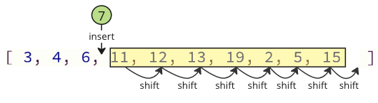

Operasi pergeseran ini dapat memakan banyak waktu, terutama untuk array dengan banyak elemen.